# ICA 2

Alice Trejo

MSBA Data Analytics III

## Learning Objectives

In this assignment, you will practice your T-Test and R programming skills. You will use a fixed effects model and perform a difference-in-differences analysis. Please answer the questions in a R markdown file and “Knit” the file so that I can see your analysis.

## Experiments

Reanalysis of Gerber, Green and Larimer (2008) ‘Why do large numbers of people vote, despite the fact that, as Hegel once observed, “the casting of a single vote is of no significance where there is a multitude of electors”?’

This is the question that drives the experimental analysis of Gerber, Green and Larimer (2008). If it is irrational to vote because the costs of doings so (time spent informing oneself, time spent getting to the polling station, etc) are clearly greater than the gains to be made from voting (the probability that any individual voter will be decisive in an election are vanishingly small), then why do we observe millions of people voting in elections? One commonly proposed answer is that voters may have some sense of civic duty which drives them to the polls. Gerber, Green and Larimer investigate this idea empirically by priming voters to think about civic duty while also varying the amount of social pressure voters are subject to. In a field experiment in advance of the 2006 primary election in Michigan, nearly 350,000 voters were assigned at random to one of four treatment groups, where voters received mailouts which encouraged them to vote, or a control group where voters received no mailout. The treatment and control conditions were as follows:

```
Treatment 1 (“Civic duty”): Voters receive mailout reminding them that voting is a civic duty
Treatment 2 (“Hawthorne”): Voters receive mailout telling them that researchers would be studying their turnout based on public records
Treatment 3 (“Self”): Voters receive mailout displaying the record of turnout for their household in prior elections.
Treatment 4 (“Neighbors”): Voters receive mailout displaying the record of turnout for their household and their neighbours’ households in prior elections.
Control: Voters receive no mailout.
```

Load the replication data for Gerber, Green and Larimer (2008). This data is stored in a .Rdata format, which is the main way to save data in R. Therefore you will not be able to use read.csv but instead should use the function load.

```r
# You will need to change the file location for the code to work.
load("gerber_green_larimer.Rdata")
```

Once you have loaded the data, familiarise yourself with the the gerber object which should be in your current envionment. Use the str and summary functions to get an idea of what is in the data. There are 5 variables in this data.frame: Variable name Description

- voted: Indicator for whether the voter voted in the 2006 election (1) or did not vote (0)
- treatment: Factor variable indicating which treatment arm (or control group) the voter was allocated to
- sex: Sex of the respondent
- yob: Year of birth of the respondent
- p2004: Indicator for whether the voter voted in the 2004 election (Yes) or not (No)
1. Calculate the turnout rates, “voted”, for each of the experimental groups (4 treatments, 1 control). Calculate the number of individuals allocated to each group. Recreate table 2 on p. 38 of the paper.

```r
library(modelsummary)
datasummary(voted ~ Mean*factor(treatment), data=gerber)
```

|  | Control | Civic Duty | Hawthorne | Self | Neighbors |
| --- | --- | --- | --- | --- | --- |
| voted | 0.30 | 0.31 | 0.32 | 0.35 | 0.38 |

2. Use the following code to create three new variables in the data.frame. First, a variable that is equal to 1 if a respondent is female, and 0 otherwise. Second, a variable that measures the age of each voter in years at the time of the experiment (which was conducted in 2006). Third, a variable that is equal to 1 if the voter voted in the November 2004 Miderm election.

```r
## Female dummy variable
gerber$female <- ifelse(gerber$sex == "female", 1, 0)

## Age variable
gerber$age <- 2006 - gerber$yob

## 2004 variable
gerber$turnout04 <- ifelse(gerber$p2004 == "Yes", 1, 0)
```

3. Using these variables, conduct balance checks to establish whether there are potentially confounding differences between treatment and control groups. You do this by using the variables female, age, and turnout04 as depedent variables. Use just the factor variable of treatment as your explanatory variable. Can you conclude from the results that randomization worked? How do you know?

```r
exp1 <-lm(female ~ factor(treatment), data =gerber)
exp2 <-lm(age ~ factor(treatment), data =gerber)
exp3 <-lm(turnout04 ~ factor(treatment), data =gerber)
library(modelsummary)
modelsummary(list("Female"=exp1,"Age"=exp2,"Turnout"=exp3),coef_rename = coef_rename, stars = TRUE)
```

|  | Female | Age | Turnout |
| --- | --- | --- | --- |
| (Intercept) | 0.499*** | 49.814*** | 0.400*** |
|  | (0.001) | (0.033) | (0.001) |
| Civic Duty | 0.001 | −0.155+ | −0.001 |
|  | (0.003) | (0.081) | (0.003) |
| Hawthorne | 0.000 | −0.109 | 0.003 |
|  | (0.003) | (0.081) | (0.003) |
| Self | 0.001 | −0.021 | 0.002 |
|  | (0.003) | (0.081) | (0.003) |
| Neighbors | 0.001 | 0.039 | 0.006* |
|  | (0.003) | (0.081) | (0.003) |
| Num.Obs. | 344084 | 344084 | 344084 |
| R2 | 0.000 | 0.000 | 0.000 |
| R2 Adj. | 0.000 | 0.000 | 0.000 |
| AIC | 499477.3 | 2814316.6 | 485852.4 |
| BIC | 499541.8 | 2814381.1 | 485916.9 |
| Log.Lik. | −249732.671 | −1407152.317 | −242920.207 |
| RMSE | 0.50 | 14.45 | 0.49 |

+ p < 0.1, * p < 0.05, ** p < 0.01, *** p < 0.001

Answer: We can conclude from the results that randomization worked because there are not relevant coefficients and R2 is 0 in this case.

4. Estimate the average treatment effects of the different treatment arms whilst controlling for the variables you created for the question above. How do these estimates differ from regression estimates of the treatment effects only (i.e. without controlling for other factors)? Why?

```r
exp4 <-lm(voted ~ factor(treatment), data =gerber)
# Now use the same equation above but add female, age, and turnout04
exp5 <-lm(voted ~ factor(treatment)+female+age+turnout04, data=gerber)
modelsummary(list(exp4,exp5),coef_rename = coef_rename, stars = TRUE)
```

|  | (1) | (2) |
| --- | --- | --- |
| (Intercept) | 0.297*** | 0.044*** |
|  | (0.001) | (0.003) |
| Civic Duty | 0.018*** | 0.019*** |
|  | (0.003) | (0.003) |
| Hawthorne | 0.026*** | 0.026*** |
|  | (0.003) | (0.003) |
| Self | 0.049*** | 0.048*** |
|  | (0.003) | (0.003) |
| Neighbors | 0.081*** | 0.080*** |
|  | (0.003) | (0.003) |
| Female |  | −0.008*** |
|  |  | (0.002) |
| Age |  | 0.004*** |
|  |  | (0.000) |
| Turnout04 |  | 0.148*** |
|  |  | (0.002) |
| Num.Obs. | 344084 | 344084 |
| R2 | 0.003 | 0.045 |
| R2 Adj. | 0.003 | 0.045 |
| AIC | 448179.9 | 433501.1 |
| BIC | 448244.4 | 433597.9 |
| Log.Lik. | −224083.935 | −216741.564 |
| RMSE | 0.46 | 0.45 |

+ p < 0.1, * p < 0.05, ** p < 0.01, *** p < 0.001

Answer: The coefficients are almost the same or the same, because the randomization worked. If we add truly independent variables it shouldn’t change our coefficients.

5. Estimate the treatment effects separately for men and women. Do you note any differences in the impact of the treatment among these subgroups? Answer: There are not big differences.

```r
# modify the equation below for just men
exp6 <-lm(voted ~ factor(treatment), data =gerber[gerber$female==0, ])
# modify the equation below for just women
exp7 <-lm(voted ~ factor(treatment), data =gerber[gerber$female==1, ])
modelsummary(list("Men"=exp6,"Women"=exp7),coef_rename = coef_rename, stars = TRUE)
```

|  | Men | Women |
| --- | --- | --- |
| (Intercept) | 0.303*** | 0.290*** |
|  | (0.002) | (0.001) |
| Civic Duty | 0.020*** | 0.016*** |
|  | (0.004) | (0.004) |
| Hawthorne | 0.025*** | 0.027*** |
|  | (0.004) | (0.004) |
| Self | 0.046*** | 0.051*** |
|  | (0.004) | (0.004) |
| Neighbors | 0.082*** | 0.081*** |
|  | (0.004) | (0.004) |
| Num.Obs. | 172289 | 171795 |
| R2 | 0.003 | 0.004 |
| R2 Adj. | 0.003 | 0.003 |
| AIC | 226155.0 | 221958.4 |
| BIC | 226215.3 | 222018.8 |
| Log.Lik. | −113071.476 | −110973.214 |
| RMSE | 0.47 | 0.46 |

+ p < 0.1, * p < 0.05, ** p < 0.01, *** p < 0.001

Difference-in-Differences: Replication Exercise from the notes

The data are about the expansion of the Earned Income Tax Credit. The sample only contains single women. This legislation is aimed at providing a tax break for low income individuals. For some background on the subject, see

Eissa, Nada, and Jeffrey B. Liebman. 1996. Labor Supply Responses to the Earned Income Tax Credit. Quarterly Journal of Economics. 111(2): 605-637.

**Big Hint: Most of the code you need is in the notes**

Variable Names and Definitions

state: Factor variable containg the state’s FIPS code. year: Calendar Year urate: unemployment rate for the state and year children: number of children in the household nonwhite: the person identifies as non-White finc: Family household income earn: Earned income unearn: unearned income age: Age of the mother in years ed: Years of schooling work: Indicator variable equal to 1 if the person is currently working

The homework questions:

1. Provide Descriptive Statistics for the data. Format nicely, not just R printout. Here is an example below. I have already provided the code to read in the data below. You need to create the data summary table.

```r
require(foreign)
eitc<-read.dta("https://github.com/CausalReinforcer/Stata/raw/master/eitc.dta")
library(modelsummary)
# the data mtcars is just an example. You need to replace it with eitc
datasummary((`Unemployment Rate`=urate)+children+(`Non-white`=nonwhite)+(`Family Income`=finc)+(`Earned Income`=earn)+age+(`Years of Education`=ed)+work+(`Unearned Income`=unearn) ~ Mean + SD + Min + Max,
            data = eitc)
```

|  | Mean | SD | Min | Max |
| --- | --- | --- | --- | --- |
| Unemployment Rate | 6.76 | 1.46 | 2.60 | 11.40 |
| children | 1.19 | 1.38 | 0.00 | 9.00 |
| Non-white | 0.60 | 0.49 | 0.00 | 1.00 |
| Family Income | 15255.32 | 19444.25 | 0.00 | 575616.82 |
| Earned Income | 10432.48 | 18200.76 | 0.00 | 537880.61 |
| age | 35.21 | 10.16 | 20.00 | 54.00 |
| Years of Education | 8.81 | 2.64 | 0.00 | 11.00 |
| work | 0.51 | 0.50 | 0.00 | 1.00 |
| Unearned Income | 4.82 | 7.12 | 0.00 | 134.06 |

2. Calculate the sample means of all variables for (a) single women with no children, (b) single women with 1 child, and (c) single women with 2+ children. **Hint: Use the tidyverse to make this table. You can either filter the data or use dplyr to construct groups.You can even use datasummary to do this step. Below is one example**

```r
# Make the appropriate changes (i.e. dataframe name and correct factor variable)
eitc$nochild<-eitc$children
eitc$nochild[eitc$children>2] <-2
eitc$nochild <- factor(eitc$nochild, labels = c("No Children", "1 Child", "2 or more Children"))
datasummary((`Unemployment Rate`=urate)+children+(`Non-white`=nonwhite)+(`Family Income`=finc)+(`Earned Income`=earn)+age+(`Years of Education`=ed)+work+(`Unearned Income`=unearn) ~ mean * factor(nochild),data = eitc)
```

|  | No Children | 1 Child | 2 or more Children |
| --- | --- | --- | --- |
| Unemployment Rate | 6.66 | 6.80 | 6.86 |
| children | 0.00 | 1.00 | 2.80 |
| Non-white | 0.52 | 0.60 | 0.71 |
| Family Income | 18559.86 | 13941.57 | 11985.30 |
| Earned Income | 13760.26 | 9928.28 | 6613.55 |
| age | 38.50 | 33.76 | 32.05 |
| Years of Education | 8.55 | 8.99 | 9.01 |
| work | 0.57 | 0.54 | 0.42 |
| Unearned Income | 4.80 | 4.01 | 5.37 |

3. Construct a variable for the “treatment” called ANYKIDS. This variable should equal 1 if they have any children and zero otherwise. Create a second variable to indicate after the expansion (called POST93-should be 1 for 1994 and later).

```r
# the EITC went into effect in the year 1994
eitc$post93 = as.numeric(eitc$year >= 1994)
# The EITC only affects women with at least one child, so the
# treatment group will be all women with children.
eitc$anykids = as.numeric(eitc$children >= 1)
```

4. Create a graph which plots mean annual employment rates by year (1991-1996) for single women with children (treatment) and without children (control). **Hint: you should have two lines on the same graph.** I would suggest to use ggplot to make this plot. Here is some sample code. The variable “work” is your dependent variable.

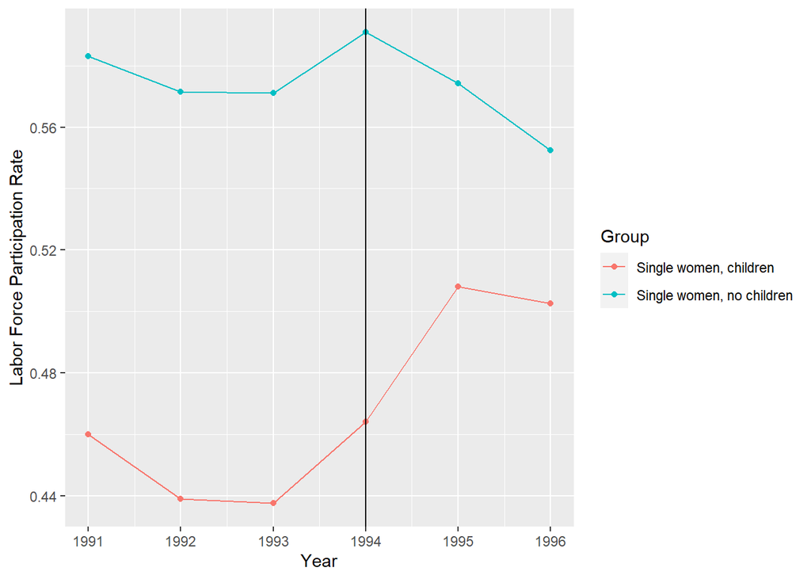

```r
minfo = aggregate(eitc$work, list(eitc$year,eitc$anykids == 1), mean)
# rename column headings (variables)
names(minfo) = c("YR","Treatment","LFPR")
# Attach a new column with labels
minfo$Group[1:6] = "Single women, no children"
minfo$Group[7:12] = "Single women, children"
#minfo
require(ggplot2)    #package for creating nice plots
qplot(YR, LFPR, data=minfo, geom=c("point","line"), colour=Group,
xlab="Year", ylab="Labor Force Participation Rate")+geom_vline(xintercept = 1994)
```

5. Do the trends between the two groups appear to be parallel? Why is this important? Answer: Yes, they appear to be parallel until the year 1994. This is important because it indicates that these both groups (Treatment and Control) are being influenced similarly by the overall economic conditions, society norms, or employment policies in place during that time (1991-1994).
6. Calculate the unconditional difference-in-difference estimates of the effect of the 1993 EITC expansion on employment of single women. **Hint: This means calculate the DID treatment effect by just subtracting means (i.e. no regression)**

```r
# Compute the four data points needed in the DID calculation:
a = sapply(subset(eitc, post93 == 0 & anykids == 0, select=work), mean)
b = sapply(subset(eitc, post93 == 0 & anykids == 1, select=work), mean)
c = sapply(subset(eitc, post93 == 1 & anykids == 0, select=work), mean)
d = sapply(subset(eitc, post93 == 1 & anykids == 1, select=work), mean)
# Compute the effect of the EITC on the employment of women with children:
(d-c)-(b-a)
```

```
##       work
## 0.04687313
```

7. Now run a regression to estimate the conditional difference-in-difference estimate of the effect of the EITC. Use all women with children as the treatment group. **Hint: your answers for 6 and 7 should match.**

```r
# Estimate a difference in difference regression. You should be using ANYKIDS and POST93 in your regression. Work is your dependent variable

reg1 <- lm(work ~ post93+anykids+post93*anykids, data = eitc)
summary(reg1)
```

```
##
## Call:
## lm(formula = work ~ post93 + anykids + post93 * anykids, data = eitc)
##
## Residuals:
##     Min      1Q  Median      3Q     Max
## -0.5755 -0.4908  0.4245  0.5092  0.5540
##
## Coefficients:
##                 Estimate Std. Error t value Pr(>|t|)
## (Intercept)     0.575460   0.008845  65.060  < 2e-16 ***
## post93         -0.002074   0.012931  -0.160  0.87261
## anykids        -0.129498   0.011676 -11.091  < 2e-16 ***
## post93:anykids  0.046873   0.017158   2.732  0.00631 **
## ---
## Signif. codes:  0 '***' 0.001 '**' 0.01 '*' 0.05 '.' 0.1 ' ' 1
##
## Residual standard error: 0.4967 on 13742 degrees of freedom
## Multiple R-squared:  0.0126, Adjusted R-squared:  0.01238
## F-statistic: 58.45 on 3 and 13742 DF,  p-value: < 2.2e-16
```

8. Re-estimate this model including demographic characteristics as well as state and year fixed effect. Use the variable nonwhite, age, ed, and unearn as demographics.

```r
#install.packages('lfe')
library(lfe)
eitc$interact <- eitc$post93*eitc$anykids
reg2 <- felm(work ~ anykids+interact+nonwhite+age+ed+unearn|state+year, data=eitc)
summary(reg2)
```

```
##
## Call:
##    felm(formula = work ~ anykids + interact + nonwhite + age + ed +      unearn | state + year, data = eitc)
##
## Residuals:
##     Min      1Q  Median      3Q     Max
## -0.9011 -0.4596  0.1867  0.4269  2.4472
##
## Coefficients:
##            Estimate Std. Error t value Pr(>|t|)
## anykids  -0.1060901  0.0114251  -9.286  < 2e-16 ***
## interact  0.0526466  0.0163114   3.228  0.00125 **
## nonwhite -0.0806300  0.0095755  -8.420  < 2e-16 ***
## age       0.0033024  0.0004217   7.830 5.23e-15 ***
## ed        0.0155543  0.0015967   9.742  < 2e-16 ***
## unearn   -0.0174273  0.0005736 -30.382  < 2e-16 ***
## ---
## Signif. codes:  0 '***' 0.001 '**' 0.01 '*' 0.05 '.' 0.1 ' ' 1
##
## Residual standard error: 0.4711 on 13684 degrees of freedom
## Multiple R-squared(full model): 0.1156   Adjusted R-squared: 0.1116
## Multiple R-squared(proj model): 0.08644   Adjusted R-squared: 0.08237
## F-statistic(full model):29.31 on 61 and 13684 DF, p-value: < 2.2e-16
## F-statistic(proj model): 215.8 on 6 and 13684 DF, p-value: < 2.2e-16
```

9. Explain why you can’t use finc, earn, and uearn in the same regression.

Answer: You can’t use finc, earn, and uearn variable in the same regression, because you get perfect multicolinearity.

10. Estimate a “placebo” treatment model. Take data from only the pre-reform period. Use the same treatment and control groups. Introduce a placebo policy that begins in 1992 instead of 1994 (so 1992 and 1993 both have this fake policy).

```r
eitc$post91 = as.numeric(eitc$year >= 1992)

reg3 <- lm(work ~ post91*anykids, data = eitc[eitc$year <1994, ])

cr_reg3 <- c("post93" = "Post 93", "anykids" = "Any Kids","post93:anykids"="Post93: Any kids", "interact"="Interaction", "nonwhite" = "Non-White", "age" = "Age", "ed" = "Years of Education", "unearn" = "Unearned Income","post91" = "Post 91","post91:anykids"="Post91: Any kids")

modelsummary(list("Diff-in-diff"=reg1,"Re-estimate"=reg2,"Placebo"=reg3), vcov = c("robust","iid","robust"), stars = TRUE, coef_rename = cr_reg3)
```

|  | Diff-in-diff | Re-estimate | Placebo |
| --- | --- | --- | --- |
| (Intercept) | 0.575*** |  | 0.583*** |
|  | (0.009) |  | (0.015) |
| Post 93 | −0.002 |  |  |
|  | (0.013) |  |  |
| Any Kids | −0.129*** | −0.106*** | −0.123*** |
|  | (0.012) | (0.011) | (0.020) |
| Post93: Any kids | 0.047** |  |  |
|  | (0.017) |  |  |
| Interaction |  | 0.053** |  |
|  |  | (0.016) |  |
| Non-White |  | −0.081*** |  |
|  |  | (0.010) |  |
| Age |  | 0.003*** |  |
|  |  | (0.000) |  |
| Years of Education |  | 0.016*** |  |
|  |  | (0.002) |  |
| Unearned Income |  | −0.017*** |  |
|  |  | (0.001) |  |
| Post 91 |  |  | −0.012 |
|  |  |  | (0.018) |
| Post91: Any kids |  |  | −0.010 |
|  |  |  | (0.024) |
| Num.Obs. | 13746 | 13746 | 7401 |
| R2 | 0.013 | 0.116 | 0.017 |
| R2 Adj. | 0.012 | 0.112 | 0.016 |
| AIC | 19779.8 | 18382.1 | 10628.4 |
| BIC | 19817.5 | 18856.4 | 10663.0 |
| Log.Lik. | −9884.917 |  | −5309.218 |
| RMSE | 0.50 | 0.47 | 0.50 |
| Std.Errors | HC3 | IID | HC3 |

+ p < 0.1, * p < 0.05, ** p < 0.01, *** p < 0.001